# Statystyczna analiza danych - projekt

Paweł Strzępka

#### Odczyt danych z pliku arkusza oraz ich obróbka

Dane pochodzą ze zbiorów Głównego Urzędu Statystycznego z Biutelynu Statystycznego Nr 4/2023 z dnia 25.05.2023 o częstotliwości miesięcznej. Zawierają dane z zakresu obszaru przemysłu gospodarki narodowej. Dotyczą produkcji sprzedanej przemysłu podanej w milionach PLN od roku 2010 do początku roku 2023.

```r
getwd()
```

```
## [1] "D:/materialystudia/Statystycznaanaliza/Projekt"
```

```r
library(readxl)
#### Odczyt  danych z pliku arkusza oraz ich obrobka ####
daneraw <- read_excel("tabl46_produkcja_sprzedana_przemyslu.xlsx")
dane <- daneraw[-c(1:3),]
dane <- dane[-2,]
dane0 <- dane[,1]
dane1 <- dane[,8]
dane2 <- dane[,10]
danew <- data.frame(dane0, dane1, dane2)
colnames(danew) <- c("Miesiac", "Przetworstwo przemyslowe", "Produkcja artykulow spozywczych")
danew <- danew[-1,]
danew[,2] <- as.numeric(danew[,2])
danew[,3] <- as.numeric(danew[,3])
danew
```

```
##      Miesiac Przetworstwo przemyslowe Produkcja artykulow spozywczych
## 2   2010 M01                  53435.6                         10545.7
## 3   2010 M02                  55489.7                         10532.7
## 4   2010 M03                  67369.8                         13023.2
## 5   2010 M04                  61939.4                         10900.3
## 6   2010 M05                  64897.9                         11814.8
## 7   2010 M06                  70275.9                         12120.8
## 8   2010 M07                  66276.0                         11849.2
## 9   2010 M08                  64774.8                         12166.0
## 10  2010 M09                  73338.2                         12550.8
## 11  2010 M10                  71518.1                         13035.0
## 12  2010 M11                  70224.0                         13037.8
## 13  2010 M12                  66536.8                         12931.0
## 14  2011 M01                  62625.6                         11997.4
## 15  2011 M02                  66101.8                         12263.5
```

[output cut: 143 more lines]

#### Cecha nr 1 Przetworstwo przemyslowe

Wyznaczenie najmniejszej wartości

```r
#### Minimum C1 ####
minimumc1 <- min(danew$`Przetworstwo przemyslowe`)
minimumc1
```

```
## [1] 53435.6
```

Wyznaczenie największej wartości

```r
#### Maskimum C1####
maksimumc1 <- max(danew$`Przetworstwo przemyslowe`)
maksimumc1
```

```
## [1] 189096.2
```

Rozstęp jest najprostszą miarą rozproszenia (zmienności). Jest różnicą między wartością maksymalną a minimalną ze zbioru obserwacji. Pokazuje zatem jedynie jaki jest zakres obserwacji

```r
#### Rozstep C1####
rozstepc1 <- maksimumc1 - minimumc1
rozstepc1
```

```
## [1] 135660.6
```

Wartość średnia pochodzi z sumowania poszczególnych wyników i podzielenie tej sumy przez liczbę naszych obserwacji.

```r
#### Srednia C1####

sredniac1 <- mean(danew$`Przetworstwo przemyslowe`)
sredniac1
```

```
## [1] 99792.19
```

Mediana to wartość cechy w szeregu uporządkowanym, powyżej i poniżej której znajduje się jednakowa liczba obserwacji. Mediana jest kwantylem rzędu 1/2

```r
#### Mediana C1####

medianac1 <- median(danew$`Przetworstwo przemyslowe`)
medianac1
```

```
## [1] 91378.6
```

Odchylenie standardowe określa, jak szeroko wartości jakiejś wielkości są rozrzucone wokół jej średniej

```r
#### Odchylenie standardowe C1####

odchyleniec1 <- sd(danew$`Przetworstwo przemyslowe`)
odchyleniec1
```

```
## [1] 29589.14
```

Kwartyle to wartości, które dzielą zebrane obserwacje na cztery równe, co do ilości elementów, grupy.

```r
#### Kwartyle C1####

kwartylec1 <- quantile(danew$`Przetworstwo przemyslowe`)
kwartylec1
```

```
##       0%      25%      50%      75%     100%
##  53435.6  79201.6  91378.6 110371.0 189096.2
```

Wysoka wartość współczynnika oznacza duże zróżnicowanie cechy i świadczy o niejednorodności badanej populacji, niska wartość świadczy o małej zmienności cechy i jednorodności badanej populacji. Współczynnik zmienności jest ilorazem (wynikiem dzielenia) odchylenia standardowego cechy oraz jej średniej arytmetycznej.

```r
#### Wspolczynnik zmiennosci C1####

wszmiennoscic1 <- (odchyleniec1/sredniac1) * 100
wszmiennoscic1
```

```
## [1] 29.65076
```

Wariancja informuje, jak bardzo zróżnicowany jest zbiór pod kątem koncentracji wokół średniej bądź też rozproszenia. Wartość zero oznacza identyczne wartości w zbiorze.

```r
#### Wariancja C1####

wariancjac1 <- var(danew$`Przetworstwo przemyslowe`)
wariancjac1
```

```
## [1] 875517367
```

Trzeci moment centralny przyjmuje wartość zero dla rozkładu symetrycznego, wartości ujemne dla rozkładów o lewostronnej asymetrii i wartości dodatnie dla rozkładów o prawostronnej asymetrii.

```r
#### Moment centralny rzedu 3 C1####

library(moments)
M3C1 <- moment(danew$`Przetworstwo przemyslowe`, order=3, central=TRUE)
M3C1
```

```
## [1] 3.496676e+13
```

Jeśli wartość współczynnika asymetrii jest równy zero, oznacza to, że rozkład jest symetryczny. Ujemne wartości wskazują na skośność w lewo, natomiast dodatnie wartości wskazują na skośność w prawo.

```r
#### Wspolczynnik asymetrii ####

wsp_asymetriic1 <- skewness(danew$`Przetworstwo przemyslowe`)
wsp_asymetriic1
```

```
## [1] 1.362765
```

```r
#### Graficzna reprezentacja danych C1####
```

Wykres paskowy

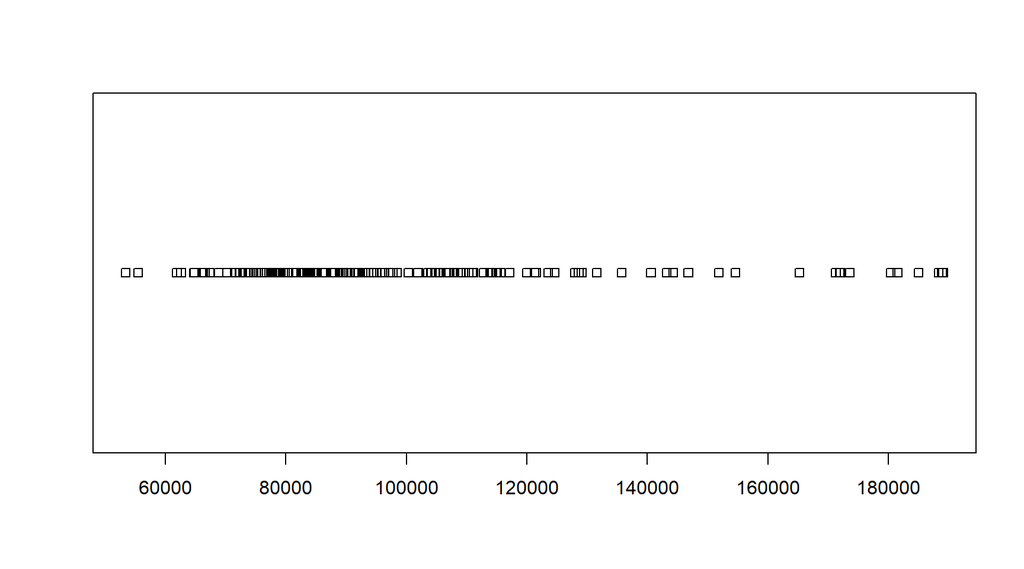

```r
#### Wykres paskowy ####
library(graphics)
stripchart(danew$`Przetworstwo przemyslowe`)
```

Histogram służy do przedstawienia liczebności obserwacji danych w zadanych przedziałach badanej zmiennej.

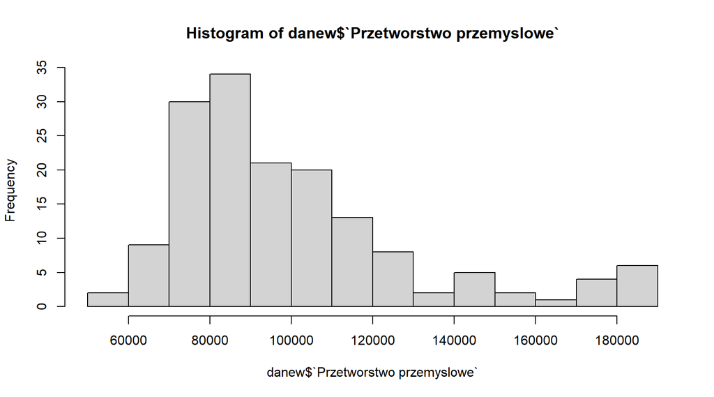

```
## $breaks
##  [1]  50000  60000  70000  80000  90000 100000 110000 120000 130000 140000
## [11] 150000 160000 170000 180000 190000
##
## $counts
##  [1]  2  9 30 34 21 20 13  8  2  5  2  1  4  6
##
## $density
##  [1] 1.273885e-06 5.732484e-06 1.910828e-05 2.165605e-05 1.337580e-05
##  [6] 1.273885e-05 8.280255e-06 5.095541e-06 1.273885e-06 3.184713e-06
## [11] 1.273885e-06 6.369427e-07 2.547771e-06 3.821656e-06
##
## $mids
##  [1]  55000  65000  75000  85000  95000 105000 115000 125000 135000 145000
## [11] 155000 165000 175000 185000
##
## $xname
## [1] "danew$`Przetworstwo przemyslowe`"
##
## $equidist
## [1] TRUE
##
## attr(,"class")
## [1] "histogram"
```

```r
#### Histogram ####
(hist(danew$`Przetworstwo przemyslowe`, breaks=13))
```

Dystrybuanta empiryczna to dystrybuanta wyliczona wprost z danych. W takiej sytuacji nie znamy prawdziwego rozkładu i bazujemy tylko na dostępnych obserwacjach

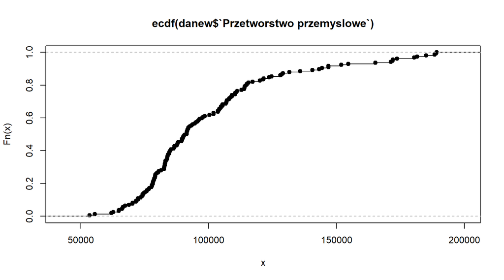

```r
#### Dystrybuanta ####
plot(ecdf(danew$`Przetworstwo przemyslowe`))
```

Wykres pudełkowy zawiera informacje odnośnie położenia, rozproszenia i kształtu rozkładu danych. Zawiera mediane, rozstęp ćwiartkowy oraz wartości odstające, które odbiegają od reszty.

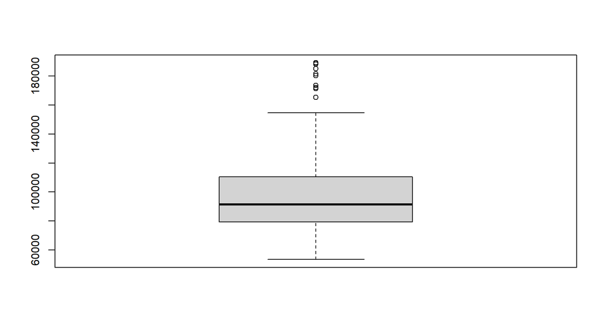

```r
#### Wykres pudełkowy ####
boxplot(danew$`Przetworstwo przemyslowe`)
```

```r
#### Hipotezy C1####
```

Hipoteza zerowa: Średnia wartość jest równa 100000 Hipoteza alternatywna: Średnia wartość nie jest równa 100000

Nie ma podstaw do odrzucenia hipotezy zerowej

```r
#hipoteza 1 Średnia wartość jest równa 102000
t.test(danew$`Przetworstwo przemyslowe`,mu = 100000)
```

```
##
##  One Sample t-test
##
## data:  danew$`Przetworstwo przemyslowe`
## t = -0.088002, df = 156, p-value = 0.93
## alternative hypothesis: true mean is not equal to 1e+05
## 95 percent confidence interval:
##   95127.6 104456.8
## sample estimates:
## mean of x
##  99792.19
```

Hipoteza zerowa: Populacja ma rozkład normalny Hipoteza alternatywna: Populacja nie ma rozkładu normalnego

Odrzucamy hipotezę zerową na korzyść hipotezy alternatywnej

```r
# hipoteza 2 dane mają rozkład normalny
shapiro.test(danew$`Przetworstwo przemyslowe`)
```

```
##
##  Shapiro-Wilk normality test
##
## data:  danew$`Przetworstwo przemyslowe`
## W = 0.86872, p-value = 1.649e-10
```

#### Cecha nr 2 Produkcja artykulow spozywczych

```r
#### Minimum C2####
minimumc2 <- min(danew$`Produkcja artykulow spozywczych`)
minimumc2
```

```
## [1] 10532.7
```

```r
#### Maskimum C2####
maksimumc2 <- max(danew$`Produkcja artykulow spozywczych`)
maksimumc2
```

```
## [1] 35687.8
```

```r
#### Rozstep C2####
rozstepc2 <- maksimumc2 - minimumc2
rozstepc2
```

```
## [1] 25155.1
```

```r
#### Srednia C2####

sredniac2 <- mean(danew$`Produkcja artykulow spozywczych`)
sredniac2
```

```
## [1] 18646.42
```

```r
#### Mediana C2####

medianac2 <- median(danew$`Produkcja artykulow spozywczych`)
medianac2
```

```
## [1] 17193
```

```r
#### Odchylenie standardowe C2####

odchyleniec2 <- sd(danew$`Produkcja artykulow spozywczych`)
odchyleniec2
```

```
## [1] 5319.669
```

```r
#### Kwantyle C2####

kwartylec2 <- quantile(danew$`Produkcja artykulow spozywczych`)
kwartylec2
```

```
##      0%     25%     50%     75%    100%
## 10532.7 15430.5 17193.0 20570.8 35687.8
```

```r
#### Wspolczynnik zmiennosci C2####

wszmiennoscic2 <- (odchyleniec2/sredniac2) * 100
wszmiennoscic2
```

```
## [1] 28.52917
```

```r
#### Wariancja C2####

wariancjac2 <- var(danew$`Produkcja artykulow spozywczych`)
wariancjac2
```

```
## [1] 28298875
```

```r
#### Moment centralny rzedu 3 C2####

library(moments)

M3C2 <- moment(danew$`Produkcja artykulow spozywczych`, order=3, central=TRUE)
M3C2
```

```
## [1] 218147285949
```

```r
#### Wspolczynnik asymetrii ####

wsp_asymetriic2 <- skewness(danew$`Produkcja artykulow spozywczych`)
wsp_asymetriic2
```

```
## [1] 1.463048
```

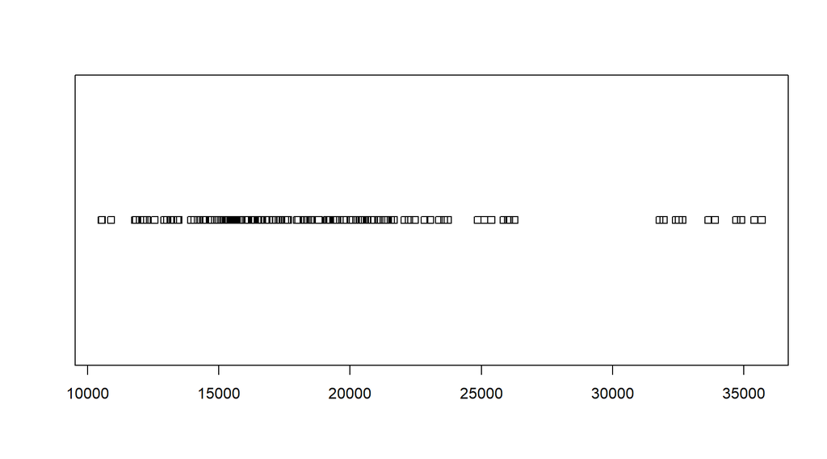

```r
#### Graficzna reprezentacja danych C2####


#### Wykres paskowy ####
library(graphics)
stripchart(danew$`Produkcja artykulow spozywczych`)
```

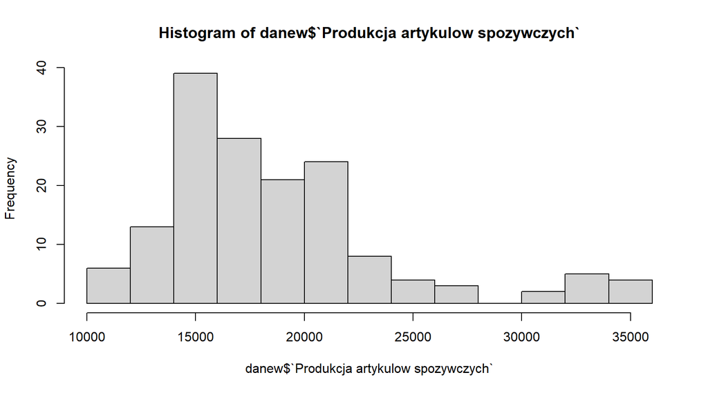

```
## $breaks
##  [1] 10000 12000 14000 16000 18000 20000 22000 24000 26000 28000 30000 32000
## [13] 34000 36000
##
## $counts
##  [1]  6 13 39 28 21 24  8  4  3  0  2  5  4
##
## $density
##  [1] 1.910828e-05 4.140127e-05 1.242038e-04 8.917197e-05 6.687898e-05
##  [6] 7.643312e-05 2.547771e-05 1.273885e-05 9.554140e-06 0.000000e+00
## [11] 6.369427e-06 1.592357e-05 1.273885e-05
##
## $mids
##  [1] 11000 13000 15000 17000 19000 21000 23000 25000 27000 29000 31000 33000
## [13] 35000
##
## $xname
## [1] "danew$`Produkcja artykulow spozywczych`"
##
## $equidist
## [1] TRUE
##
## attr(,"class")
## [1] "histogram"
```

```r
#### Histogram ####
(hist(danew$`Produkcja artykulow spozywczych`, breaks=13))
```

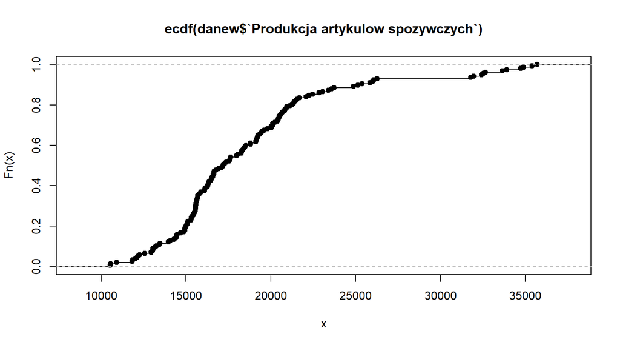

```r
#### Dystrybuanta ####
plot(ecdf(danew$`Produkcja artykulow spozywczych`))
```

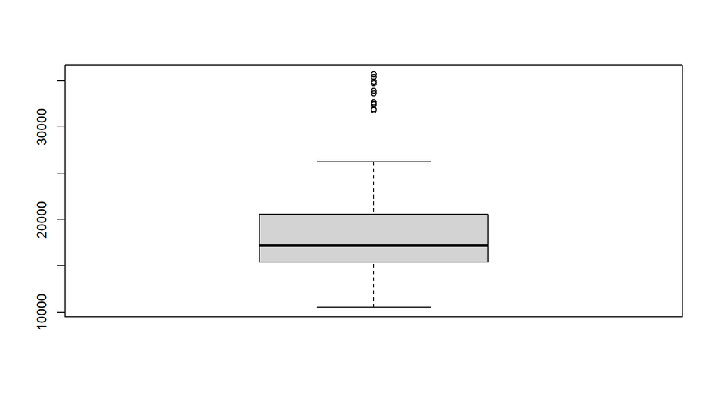

```r
#### Wykres pudełkowy ####
boxplot(danew$`Produkcja artykulow spozywczych`)
```

Hipoteza zerowa: Średnia wartość jest równa 19000 Hipoteza alternatywna: Średnia wartość nie jest równa 19000

Nie ma podstaw do odrzucenia hipotezy zerowej

```r
#### Hipotezy C2####

#hipoteza 1 Średnia wartość jest równa 19000
t.test(danew$`Produkcja artykulow spozywczych`,mu = 19000)
```

```
##
##  One Sample t-test
##
## data:  danew$`Produkcja artykulow spozywczych`
## t = -0.83283, df = 156, p-value = 0.4062
## alternative hypothesis: true mean is not equal to 19000
## 95 percent confidence interval:
##  17807.80 19485.04
## sample estimates:
## mean of x
##  18646.42
```

Hipoteza zerowa: Populacja ma rozkład normalny Hipoteza alternatywna: Populacja nie ma rozkładu normalnego

Odrzucamy hipotezę zerową na korzyść hipotezy alternatywnej

```r
# hipoteza 2 dane mają rozkład normalny
shapiro.test(danew$`Produkcja artykulow spozywczych`)
```

```
##
##  Shapiro-Wilk normality test
##
## data:  danew$`Produkcja artykulow spozywczych`
## W = 0.86382, p-value = 9.605e-11
```

#### Opis użytych funkcji:

getwd() - funkcja służy do pobrania bieżącego katalogu roboczego.

read_excel() - funkcja z pakietu “readxl” służy do odczytu pliku Excel do R i przechowywania danych w zmiennej.

data.frame() - funkcja z pakietu “base” tworzy ramkę danych na podstawie wektorów lub zmiennych. Używana jest do utworzenia nowej ramki danych o nazwie danew, łączącej wybrane kolumny z ramki danych daneraw.

colnames() - funkcja z pakietu “base” służy do nadania nazw kolumnom w ramce danych danew.

as.numeric() - funkcja z pakietu “base” służy do konwersji wybranych kolumn danew na format liczbowy.

min() - funkcja z pakietu “base” oblicza najmniejszą wartość wektora lub kolumny.

max() - funkcja z pakietu “base” oblicza największą wartość wektora lub kolumny.

mean() - funkcja z pakietu “base” oblicza średnią arytmetyczną wektora lub kolumny.

median() - funkcja z pakietu “stats” oblicza medianę wektora lub kolumny.

sd() - funkcja z pakietu “stats” oblicza odchylenie standardowe wektora lub kolumny.

quantile() - funkcja z pakietu “stats” oblicza kwantyle wektora lub kolumny.

var() - funkcja z pakietu “stats” oblicza wariancję wektora lub kolumny.

moment() - funkcja pochodzi z pakietu “moments”, który udostępnia funkcje do obliczania momentów rozkładu. Została użyta do obliczenia trzeciego momentu centralnego

skewness() - funkcja z pakietu “moments” oblicza współczynnik asymetrii dla danej populacji. W wyniku otrzymasz wartość współczynnika asymetrii.

stripchart() - funkcja z pakietu “graphics” pochodzi z podstawowego pakietu graficznego w R. Służy do tworzenia wykresu paskowego (diagram punktowy).

hist() - funkcja z pakietu “graphics” służy do tworzenia histogramu dla określonej zmiennej.

ecdf() - funkcja z pakietu “stats” służy do tworzenia empirycznej funkcji dystrybucji skumulowanej (ECDF) dla określonej zmiennej.

boxplot() - funkcja z pakietu “graphics” służy do tworzenia wykresu pudełkowego dla określonej zmiennej.

t.test() - funkcja z pakietu “stats” służy do przeprowadzania testu t, który porównuje średnią próbkową z daną wartością lub wykonuje test t dwóch próbek.

shapiro.test() - funkcja z pakietu “stats” służy do przeprowadzania testu Shapiro-Wilka, który testuje hipotezę zerową, że populacja ma rozkład normalnego.